# GLM

Richard J. Telford

```r
knitr::opts_chunk$set(echo = TRUE)
```

# Exercises GLM

## Poisson GLM

1. Import sorich.csv

```r
# Importing data
sorich.df <- read.csv("sorich.csv")
```

2. Fit a linear model for species richness (nsp) against cover assuming a Normal distribution

```r
# Fitting model (adapted from lecture)
fit_lm <- lm(nsp ~ cover, data = sorich.df)

# Checking p-values for model - looks good, model is statistically significant
summary(fit_lm)
```

```
##
## Call:
## lm(formula = nsp ~ cover, data = sorich.df)
##
## Residuals:
##     Min      1Q  Median      3Q     Max
## -6.5292 -1.3911 -0.3642  0.8508 14.2558
##
## Coefficients:
##             Estimate Std. Error t value Pr(>|t|)
## (Intercept)  0.57920    0.16880   3.431 0.000636 ***
## cover        0.59500    0.04476  13.292  < 2e-16 ***
## ---
## Signif. codes:  0 '***' 0.001 '**' 0.01 '*' 0.05 '.' 0.1 ' ' 1
##
## Residual standard error: 2.337 on 690 degrees of freedom
## Multiple R-squared:  0.2039, Adjusted R-squared:  0.2027
## F-statistic: 176.7 on 1 and 690 DF,  p-value: < 2.2e-16
```

3. Study the diagnostic plots

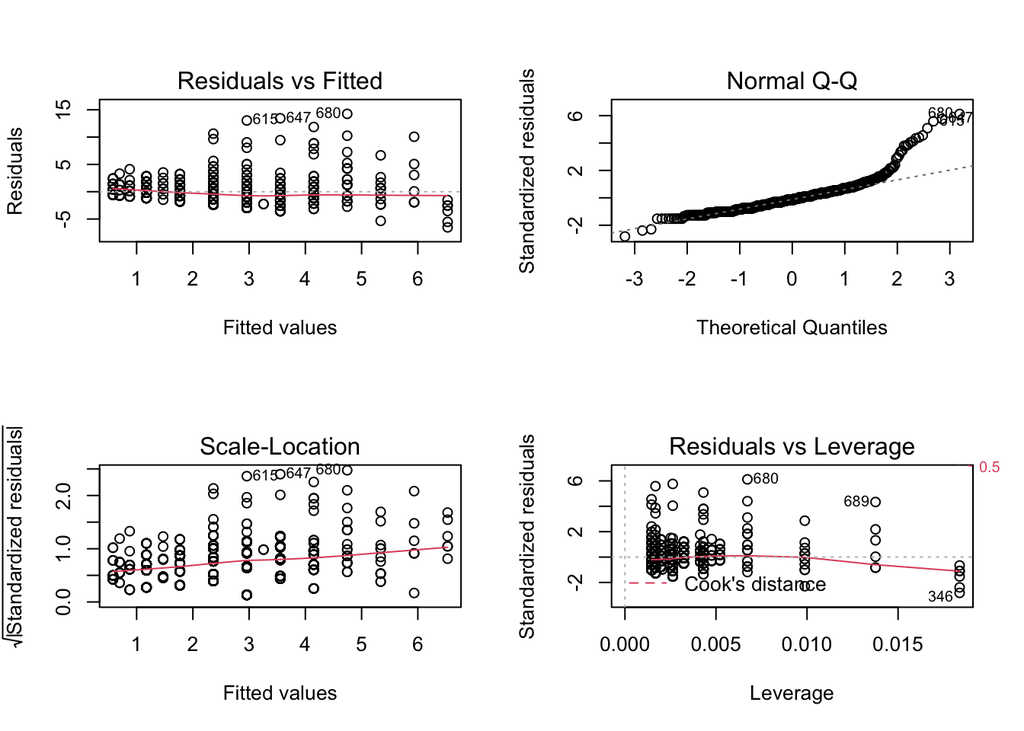

```r
# Diagnostic plots
par(mfrow = c(2,2))
plot(fit_lm)
```

```r
par(mfrow = c(1,1))
# Normal Q-Q plot does not look so good
```

*Normal Q-Q plot does not look so good, not sure about scale-location.*  
4. What distribution is the response?

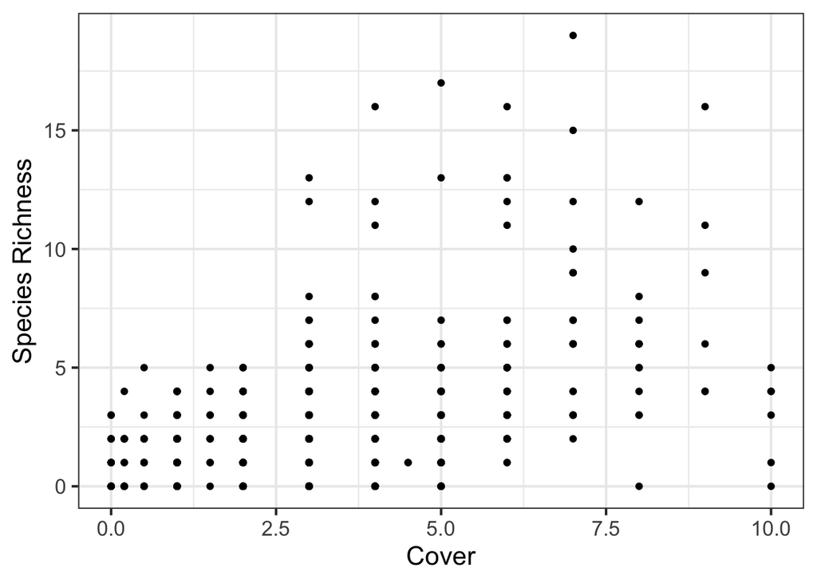

```r
# Plotting nsp ~ cover to see distribution
library(tidyverse)
ggplot(sorich.df, aes(x = cover, y = nsp)) +
  geom_point() +
  labs(y = "Species Richness", x = "Cover") +
  theme_bw(base_size = 16)
```

*The distribution of the data is not normal (gaussian), but is an example of a poisson-distributed dataset.*  
5. Do an appropriate analysis

```r
# Doing an appropriate analysis
# trying with glm and poisson distribution because data is cover aka proportion
fit_glm_poi <- glm(nsp ~ cover, data = sorich.df, family = poisson)

# Checking p-values for model
summary(fit_glm_poi) # looks good, model is statistically significant
```

```
##
## Call:
## glm(formula = nsp ~ cover, family = poisson, data = sorich.df)
##
## Deviance Residuals:
##     Min       1Q   Median       3Q      Max
## -4.2427  -1.1721  -0.1502   0.5258   5.5365
##
## Coefficients:
##             Estimate Std. Error z value Pr(>|z|)
## (Intercept)  0.17097    0.04931   3.467 0.000526 ***
## cover        0.20263    0.01037  19.541  < 2e-16 ***
## ---
## Signif. codes:  0 '***' 0.001 '**' 0.01 '*' 0.05 '.' 0.1 ' ' 1
##
## (Dispersion parameter for poisson family taken to be 1)
##
##     Null deviance: 1660.9  on 691  degrees of freedom
## Residual deviance: 1315.0  on 690  degrees of freedom
## AIC: 2869.1
##
## Number of Fisher Scoring iterations: 5
```

6. Check for over-dispersion. If necessary modify the model.

```r
# Running anova to check for overdispersion
anova(fit_glm_poi)
```

```
## Analysis of Deviance Table
##
## Model: poisson, link: log
##
## Response: nsp
##
## Terms added sequentially (first to last)
##
##
##       Df Deviance Resid. Df Resid. Dev
## NULL                    691     1660.9
## cover  1   345.95       690     1315.0
```

```r
# Residual df < Residual deviance - overdispersed
#         690 < 1315.0 --> res. dev. 2x more than res. df
```

7. Interpret the results *Resudial deviance is 2x more than residual df, i.e. the model is overdispersed*  
8. How does the width of the confidence interval at cover = 10 change when over-dispersion is allowed for

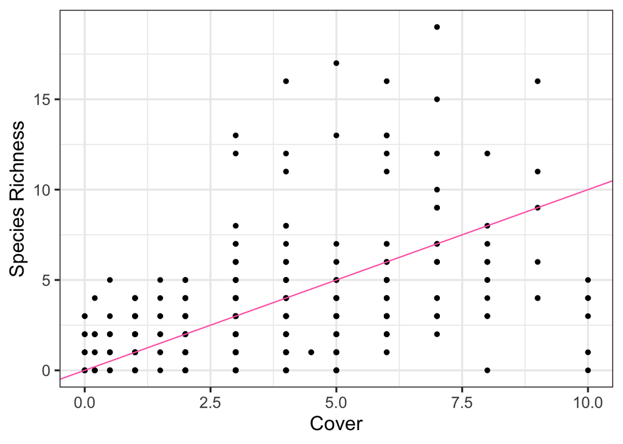

```r
# TRIED PLOTTING ON MY OWN, DID NOT TURN OUT CORRECT
# Plot of cover ~ species richness
ggplot(sorich.df, aes(x = cover, y = nsp)) +
  geom_point() +
  labs(y = "Species Richness", x = "Cover") +
  theme_bw(base_size = 16) +
# Adding model to coverplot to see if it fits tha data
  geom_abline(data = fit_glm_poi, color = "hotpink") # STRIAGHT LINE NOT CURVED :(
```

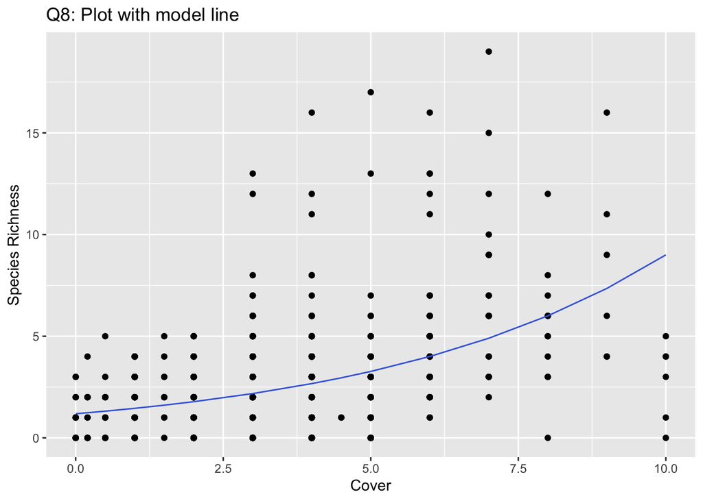

```r
# PLOT + LINE FROM LECTURE:
ggplot(cbind(sorich.df,
             fit = fitted(fit_glm_poi)), # make sure you fit the correct model
       aes(x = cover, y = nsp)) +
  geom_point() +
  geom_line(aes(y = fit), colour = "royalblue") +
  labs(y = "Species Richness", x = "Cover", title = "Q8: Plot with model line")
```

9. Do the grasses differ from the herb?  
i.e. make grassherb a factor and include it in the model and test its significance.

```r
# Checking names in sorich.df
names(sorich.df) # grasherb already a name?
```

```
## [1] "cover"    "nsp"      "grasherb"
```

```r
# Making grasherb a factor(object?) to test its significance in the model
grasherb <- sorich.df["grasherb"]
str(grasherb)
```

```
## 'data.frame':    692 obs. of  1 variable:
##  $ grasherb: int  0 0 0 0 0 0 0 0 0 0 ...
```

```r
# Including it in my model 'fit_glm_poi'
fit_glm_gh <- glm(nsp ~ cover * grasherb, data = sorich.df, family = poisson)
summary(fit_glm_gh) # it seems like grasherb is a significant term/interaction/factor
```

```
##
## Call:
## glm(formula = nsp ~ cover * grasherb, family = poisson, data = sorich.df)
##
## Deviance Residuals:
##     Min       1Q   Median       3Q      Max
## -3.3311  -1.1777  -0.2322   0.4433   5.8919
##
## Coefficients:
##                Estimate Std. Error z value Pr(>|z|)
## (Intercept)     0.63781    0.06396   9.973  < 2e-16 ***
## cover           0.10756    0.01501   7.165 7.81e-13 ***
## grasherb       -1.02320    0.10054 -10.177  < 2e-16 ***
## cover:grasherb  0.19661    0.02089   9.414  < 2e-16 ***
## ---
## Signif. codes:  0 '***' 0.001 '**' 0.01 '*' 0.05 '.' 0.1 ' ' 1
##
## (Dispersion parameter for poisson family taken to be 1)
##
##     Null deviance: 1660.9  on 691  degrees of freedom
## Residual deviance: 1208.4  on 688  degrees of freedom
## AIC: 2766.5
##
## Number of Fisher Scoring iterations: 5
```

```r
anova(fit_glm_gh)   # still overdispersed (i think?)
```

```
## Analysis of Deviance Table
##
## Model: poisson, link: log
##
## Response: nsp
##
## Terms added sequentially (first to last)
##
##
##                Df Deviance Resid. Df Resid. Dev
## NULL                             691     1660.9
## cover           1   345.95       690     1315.0
## grasherb        1    17.42       689     1297.6
## cover:grasherb  1    89.20       688     1208.4
```

## How much does over-dispersion affect results

1. Use `sample()` to randomise the response in sorich to remove the relationship between the predictor and response.
2. Test if a Poisson GLM with cover as a predictor is significant
3. Repeat 1000 times and find the distribution of p-values

## Binomial GLM and GAM

1. Open library mgcv
2. Import data pot.csv
3. What type of distribution is the response variable?
4. What type of link-function do we use?
5. Do an appropriate GLM analysis?
6. Interpret the results?
7. Do a GAM analysis
8. Compare the GLM and GAM models.
9. Which model would you prefer, and why?